# Exercise 04

Author

Gianfranco Botta (GianfrancoBotta)

Published

September 10, 2023

## Load packages

```r
library(limma)
library(ggplot2)
library(tidyverse)
library(pheatmap)
library(ROCR)
```

## Generate data

```r
nGenes <- 10000                   # number of "features"
nSamples <- 6                     # number of samples (split equal in 2 groups)
pDiff <- .1                       # percent of genes "differential"
grp <- rep(0:1,each=nSamples/2)   # dummy variable for exp. group
trueFC <- 2                       # log-fold-change of truly DE

d0 <- 1
s0 <- 0.8
sd <- s0*sqrt(d0/rchisq(nGenes,df=d0))  # dist'n of s.d.
```

grp defines the groups that are 000 111, hence the matrix is divided into two groups. s0 sets the baseline level of variability, and sd incorporates both the baseline variability and additional noise to create a more realistic representation of gene expression variation in the generated dataset. d0 is the number of degrees of freedom in the chi-squared distribution.

```r
y <- matrix(rnorm(nGenes*nSamples,sd=sd),
            nr=nGenes,nc=nSamples)
```

```r
indD <- 1:floor(pDiff*nGenes)
diff <- sample(c(-1,1),max(indD),replace=TRUE)*trueFC
y[indD,grp==1] <- y[indD,grp==1] + diff
```

We generated the indices of genes to be differentially expressed, the random differential expression values, and we added differential expression to the gene expression matrix.

## Question 1

*First, do an exploratory analysis of the true (simulated) and observed (calculated from data) variances. For the observed variances, compute the residual variance for each row of y (i.e., pooled variance of the two groups of simulated samples, not the row-wise variance; see the denominator of the classical two-sample t-statistic) and look at the distribution of them, of the true variances (from the simulated sd) and make a scatter plot of true versus observed. Often, viewing variances on the log scale is preferred.*

sd is our true standard deviation. The observed variance can be calculated from our data y. When calculating the residual variance for each row of y, it’s important to divide the table into two groups, since we have differentially expressed genes in group 1.

```r
# Compute the true variance
t_variances <- sd^2

# Divide the matrix 'y' into two parts based on the column groups
grp_0_idx <- which(grp == 0)
grp_1_idx <- which(grp == 1)
grp_0 <- y[, grp_0_idx]
grp_1 <- y[, grp_1_idx]

# Calculate observed variances separately for each group
obs_variances_grp_0 <- apply(grp_0, 1, function(row) var(row))
obs_variances_grp_1 <- apply(grp_1, 1, function(row) var(row))
```

First, we perform an exploratory data analysis of the true and observed variances by visualizing the distributions.

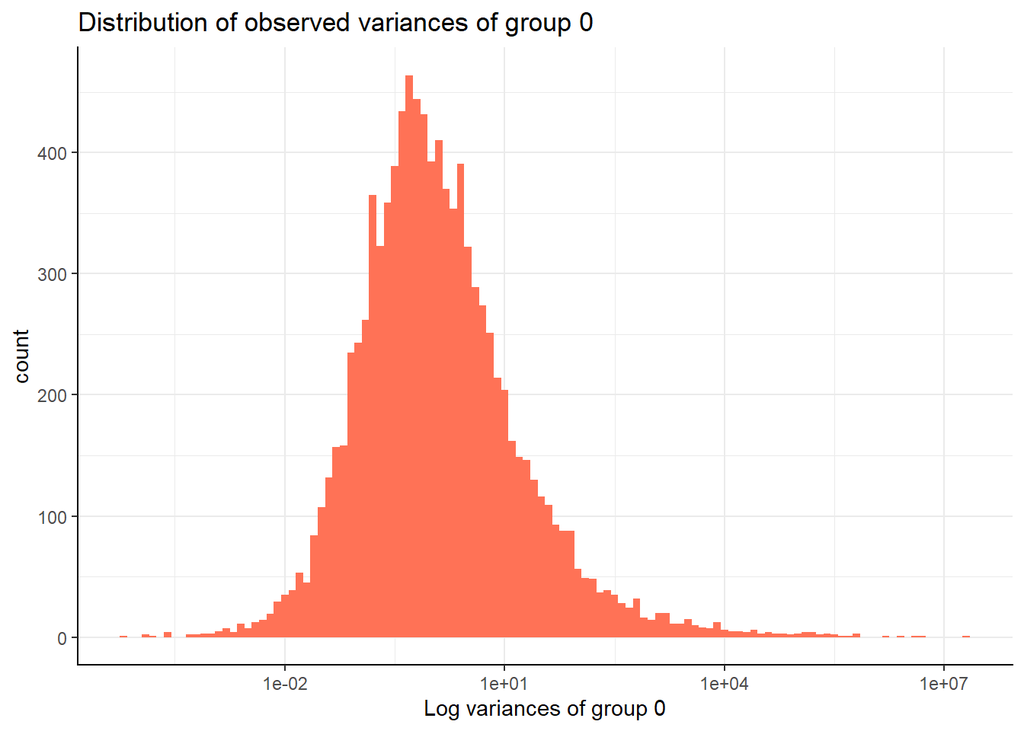

```r
# Visualize the distribution of the true variances and of the observed variances (divided in two groups)
ggplot(data = data.frame(ObsVars = obs_variances_grp_0)) +
  geom_histogram(aes(x = ObsVars),
                 binwidth = 0.1,
                 fill = "coral1") +
  theme_bw() +
  theme(
    panel.border = element_blank(),
    axis.line = element_line(color = "black", linewidth = 0.5, lineend = "square")
  ) +
  labs(title = "Distribution of observed variances of group 0",
       x = "Log variances of group 0") +
  scale_x_log10()
```

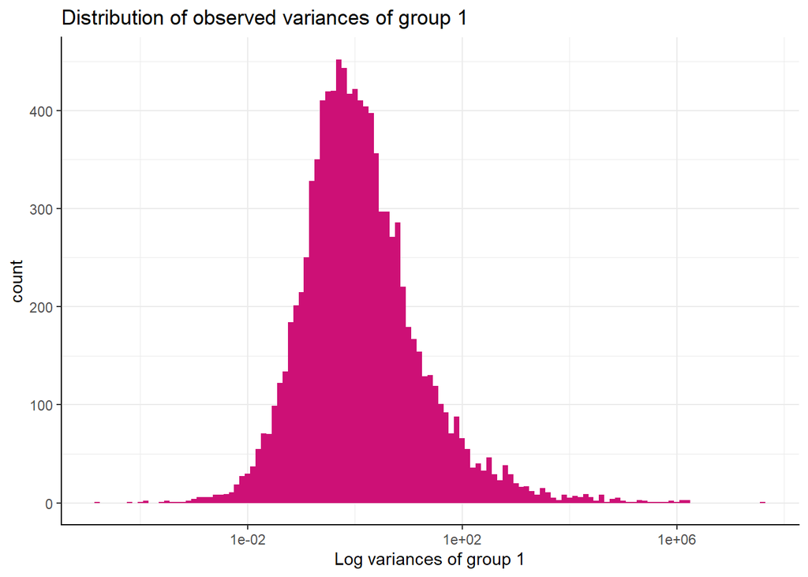

```r
ggplot(data = data.frame(ObsVars = obs_variances_grp_1)) +
  geom_histogram(aes(x = ObsVars),
                 binwidth = 0.1,
                 fill = "deeppink3") +
  theme_bw() +
  theme(
    panel.border = element_blank(),
    axis.line = element_line(color = "black", linewidth = 0.5, lineend = "square")
  ) +
  labs(title = "Distribution of observed variances of group 1",
       x = "Log variances of group 1") +
  scale_x_log10()
```

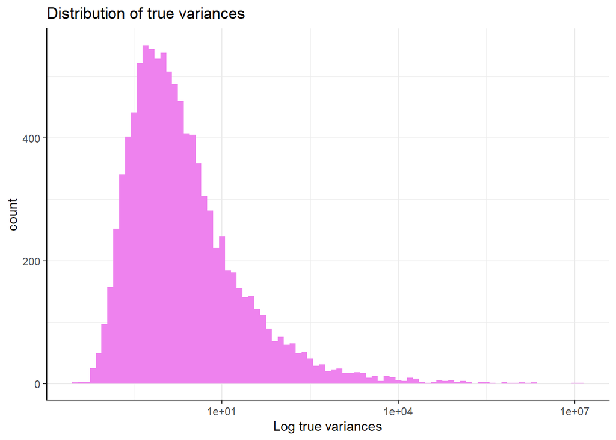

```r
ggplot(data = data.frame(TrueVars = t_variances)) +
  geom_histogram(aes(x = TrueVars),
                 binwidth = 0.1,
                 fill = "violet") +
  theme_bw() +
  theme(
    panel.border = element_blank(),
    axis.line = element_line(color = "black", linewidth = 0.5, lineend = "square")
  ) +
  labs(title = "Distribution of true variances",
       x = "Log true variances") +
  scale_x_log10()
```

We can notice that all three distributions seem to have a scaled inverse chi-squared distribution. Moreover, we can have a better understanding of the two differential distributions using violin plots.

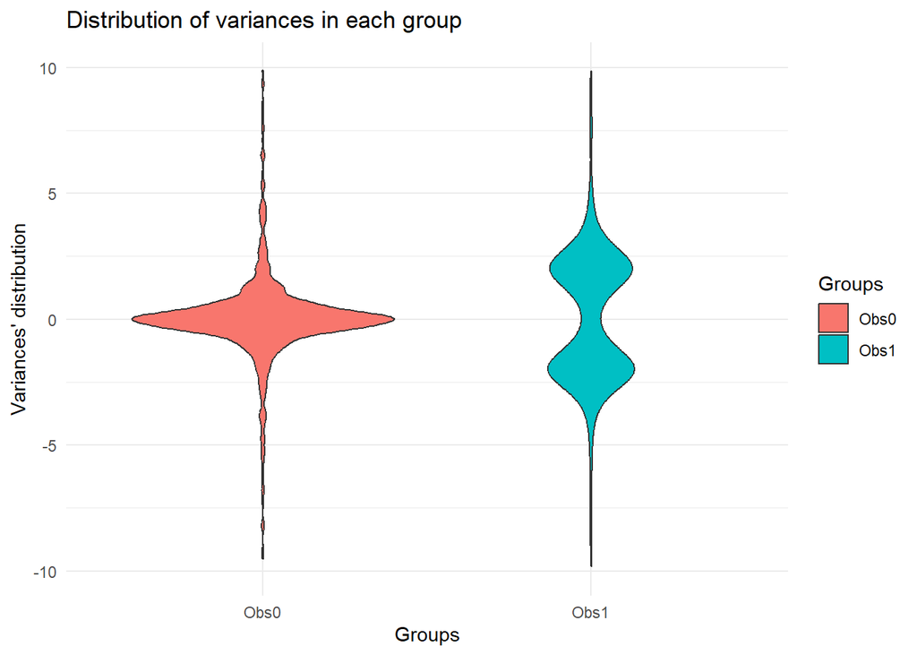

```r
violin_df <- data.frame(Obs0 = rowMeans(y[indD,grp==0]),
                      Obs1 = rowMeans(y[indD,grp==1]))

long_df <- pivot_longer(violin_df, col = colnames(violin_df), names_to = "Groups", values_to = "Values")

ggplot(long_df, aes(x = Groups, y = Values, fill = Groups)) +
  geom_violin(width=0.8) +
  ylim(-10,10) +
  labs(title="Distribution of variances in each group", x="Groups", y="Variances' distribution") +
  theme_minimal()
```

We can clearly see the difference between the two distributions. The first one represent the observed data of group 0, and the second shows the data of group 1. Each distribution contains the point only of the indices used to create differential expression on the second group. In this way, we can easily visualize how the group 1 has two peaks around the values +/- diff, where the distribution of group 0 has tails instead.

Now we calculate the residual variances for the observed data and visualize them.

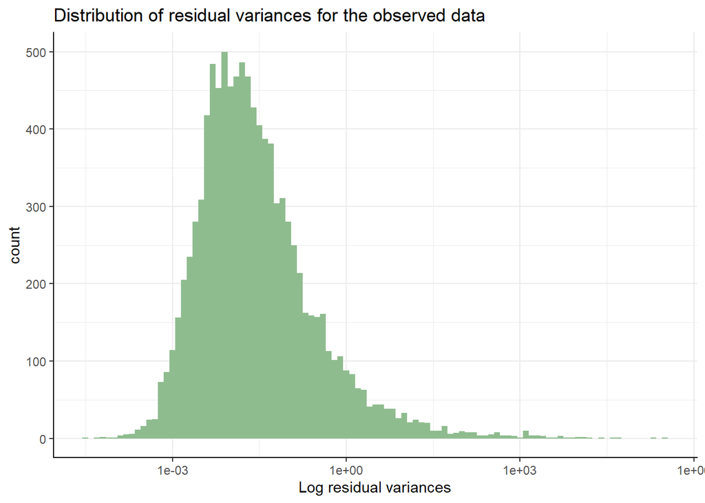

```r
res_variances <- (obs_variances_grp_0 + obs_variances_grp_1)*sqrt(1/length(grp_0) + 1/length(grp_1))

ggplot(data = data.frame(ResVars = res_variances)) +
  geom_histogram(aes(x = ResVars),
                 binwidth = 0.1,
                 fill = "darkseagreen") +
  theme_bw() +
  theme(
    panel.border = element_blank(),
    axis.line = element_line(color = "black", linewidth = 0.5, lineend = "square")
  ) +
  labs(title = "Distribution of residual variances for the observed data",
       x = "Log residual variances") +
  scale_x_log10()
```

Even the residual variances appear to have scaled inverse chi-squared distribution.

Now we can go on by plotting the true variances against the observed variances in a scatter plot.

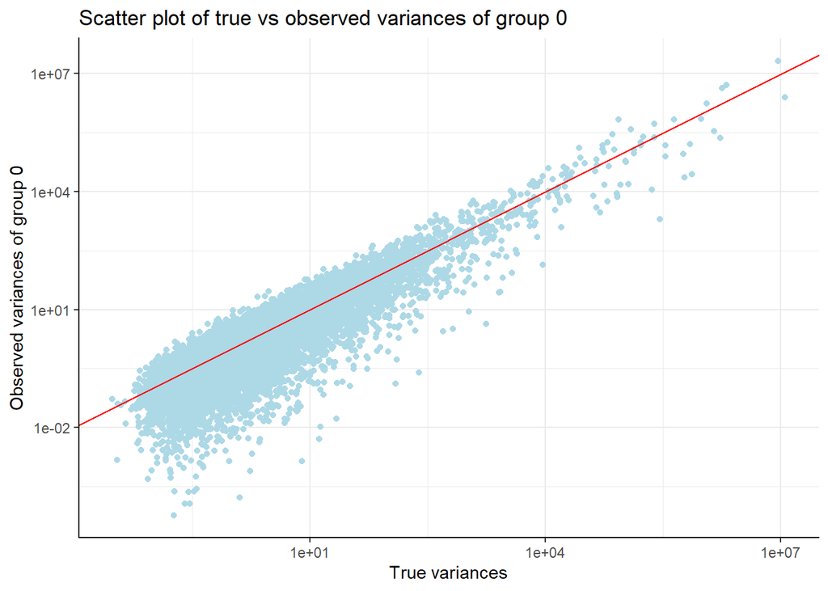

```r
vars_df <- data.frame(True = t_variances,
                      Obs0 = obs_variances_grp_0,
                      Obs1 = obs_variances_grp_1)

ggplot(vars_df, aes(x = True, y = Obs0)) +
geom_point(color="lightblue") +
theme_bw() +
  theme(
    panel.border = element_blank(),
    axis.line = element_line(color = "black", linewidth = 0.5, lineend = "square")
  ) +
  scale_x_log10() +
  scale_y_log10() +
  geom_abline(color="red") +
  labs(x = "True variances", y = "Observed variances of group 0") +
ggtitle("Scatter plot of true vs observed variances of group 0")
```

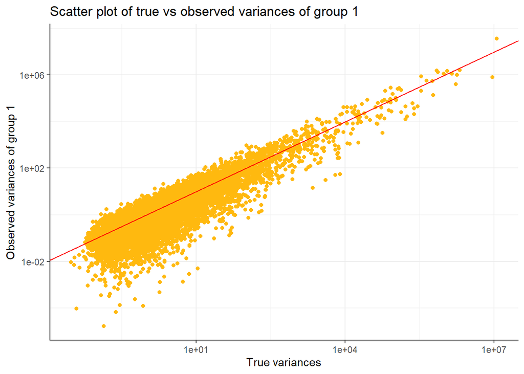

```r
ggplot(vars_df, aes(x = True, y = Obs1)) +
geom_point(color="darkgoldenrod1") +
theme_bw() +
  theme(
    panel.border = element_blank(),
    axis.line = element_line(color = "black", linewidth = 0.5, lineend = "square")
  ) +
  scale_x_log10() +
  scale_y_log10() +
  geom_abline(color="red") +
  labs(x = "True variances", y = "Observed variances of group 1") +
ggtitle("Scatter plot of true vs observed variances of group 1")
```

## Question 2

*Produce a visualization that demonstrates that you understand the “differential expression” that we introduced into the simulation. There are many possibilities; use your creativity.*

There are a lot of smart ways to visualize the differential expression introduced into the simulation, we choose to exploit the Volcano plot. Furthermore, we use “-Log10 p-value” on the y-axis as it’s a common practice in genomics. From this plot we can define some clear differences between the two groups.

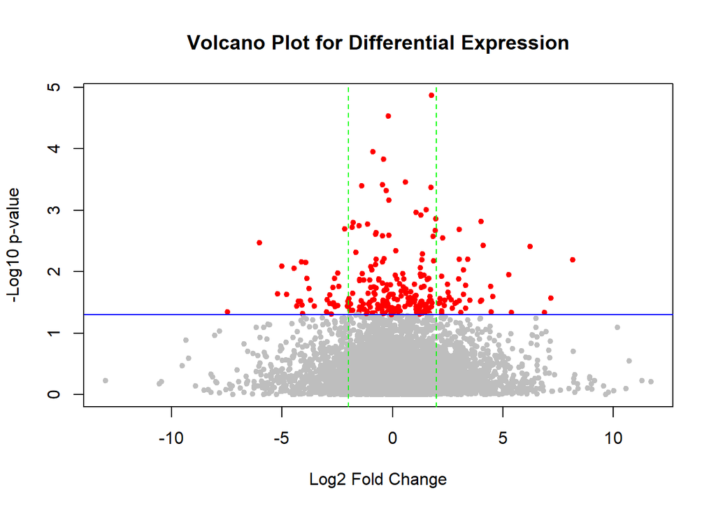

```r
# Calculate log-fold change for each gene
log_fold_change <- log2(rowMeans(grp_1) / rowMeans(grp_0))

# Generate random p-values
p_values <- runif(length(log_fold_change))

# Define a significance threshold
significance_threshold <- 0.05

# Create a volcano plot
plot(log_fold_change, -log10(p_values),
     xlab = "Log2 Fold Change",
     ylab = "-Log10 p-value",
     main = "Volcano Plot for Differential Expression",
     pch = 20, col = ifelse(p_values < significance_threshold, "red", "gray"))

# Add horizontal line for significance threshold
abline(h = -log10(significance_threshold), col = "blue")

# Add vertical lines for fold change thresholds (e.g., +/- 2)
abline(v = c(-2, 2), col = "green", lty = 2)

# Add labels for some of the most significant genes
significant_genes <- which(p_values < significance_threshold)
text(log_fold_change[significant_genes], -log10(p_values[significant_genes]),
     labels = rownames(y)[significant_genes],
     pos = 3, col = "red", cex = 0.7)
```

As we see, we set the level of significance (blue line) and then added two vertical lines (green lines) to find approximately the differential genes with a moderate degree of significance.

We can also use a heatmap where we see the expression of the differentially and non-diferentally expressed genes.

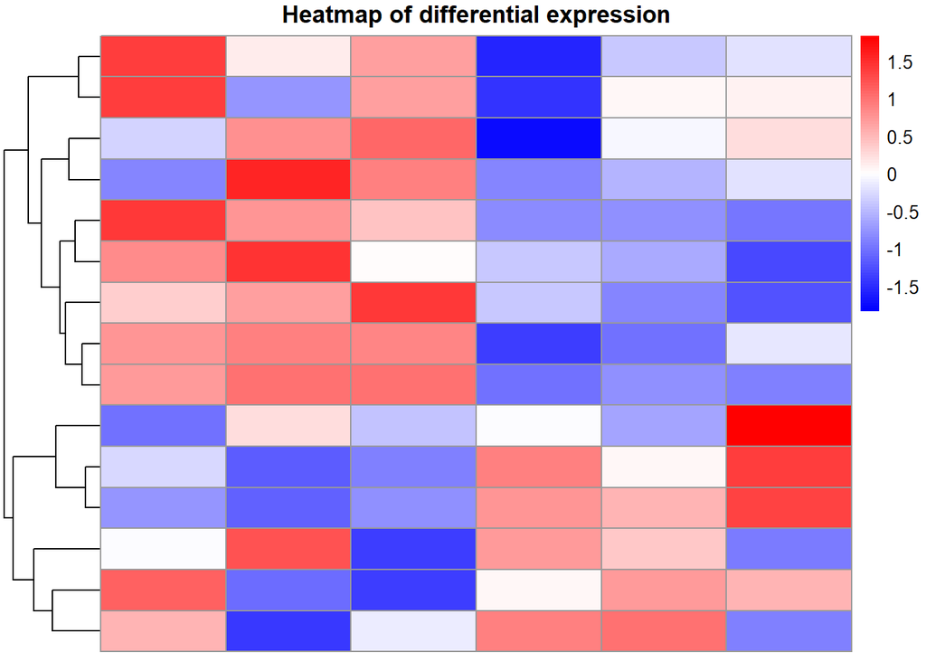

```r
# Create a matrix of fold changes with gene names as row names
fold_change = rowMeans(grp_1) / rowMeans(grp_0)

fold_change_matrix <- matrix(fold_change, nrow = length(fold_change), ncol = 1)
rownames(fold_change_matrix) <- rownames(fold_change)

sorted_genes <- rownames(fold_change_matrix)[order(abs(fold_change_matrix), decreasing = TRUE)]

sorted_indices <- order(abs(fold_change_matrix), decreasing = TRUE)

# Select the first 15 rows with the highest absolute values
best_15_rows <- as.matrix(y[sorted_indices[1:15], ])

heatmap_colors <- colorRampPalette(c("blue", "white", "red"))(100)
pheatmap(best_15_rows,
        col = heatmap_colors,
        scale = "row",
        cluster_rows = TRUE,
        cluster_cols = FALSE,
        main = "Heatmap of differential expression",
        xlab = "Samples",
        ylab = "Genes",
        margins = c(5, 10))
```

Fold change is a measure of the difference in expression of a gene or other transcripts between two different conditions. It is calculated by taking the ratio of the expression values in the two conditions. In the heatmap we can see the genes in the last three columns have been characterized with the differential expression. However, the Volcano plot seems to be the best way to visualize the differential expression introduced in the samples.

## Question 3

```r
(design <- model.matrix(~grp))
```

```
  (Intercept) grp
1           1   0
2           1   0
3           1   0
4           1   1
5           1   1
6           1   1
attr(,"assign")
[1] 0 1
```

```r
fit <- lmFit(y,design)
fit <- eBayes(fit)

names(fit)
```

```
 [1] "coefficients"     "rank"             "assign"           "qr"
 [5] "df.residual"      "sigma"            "cov.coefficients" "stdev.unscaled"
 [9] "pivot"            "Amean"            "method"           "design"
[13] "df.prior"         "s2.prior"         "var.prior"        "proportion"
[17] "s2.post"          "t"                "df.total"         "p.value"
[21] "lods"             "F"                "F.p.value"
```

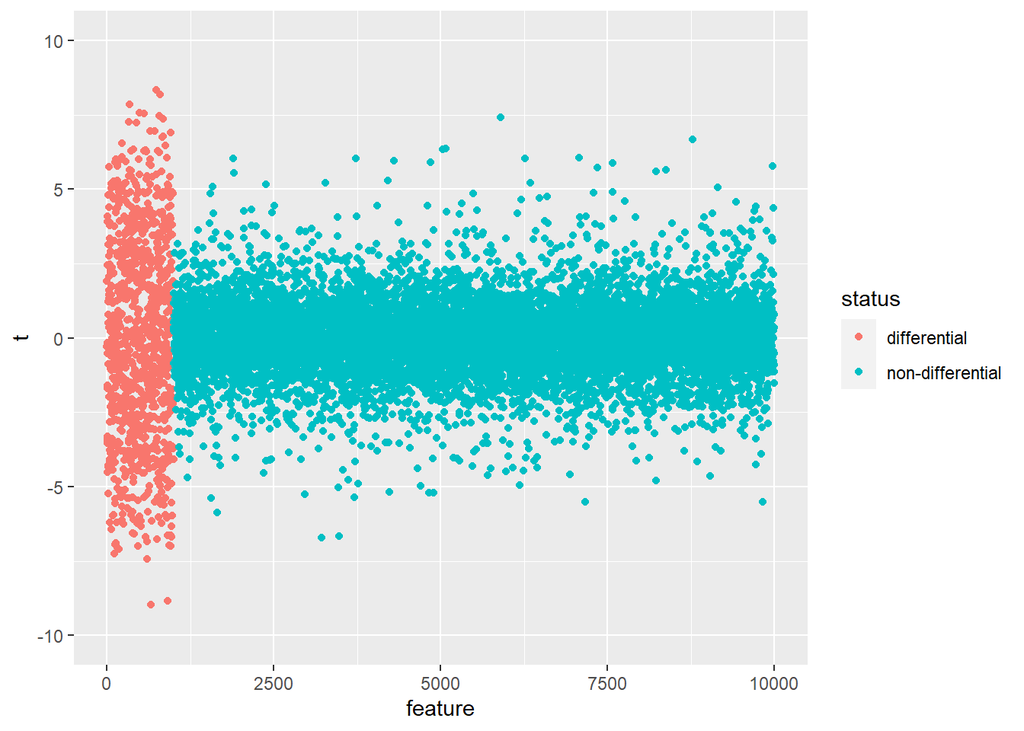

```r
cols <- rep("non-differential",nrow(y))
cols[indD] <- "differential"

df <- data.frame(feature=1:length(cols),
                 t=fit$t[,2],
                 status=cols)

ggplot(df, aes(x=feature, y=t, colour=status)) +
  geom_point() + ylim(-10,10)
```

*In practical terms, what is the interpretation of the two columns of the design matrix with the parameterization shown above?*

As seen during the lecture, the design matrix created is used to study variance through a linear model. From it we can obtain two constants α1 and α2. α1 is the log-expression of Group 0, while α2 = Group 1 - Group 0, hence it analyzes the difference between the two conditions. We can obtain this difference as the first column is made by all 1s. If there were 0s in the last three rows of the first column, it would have been α1 = Group 0 log-expression α2 = Group 1 log-expression.

In general, we can say that The first column, (the intercept), represents the intercept term of the linear model. It is a constant value (1 for all rows) and it represents the baseline or common mean across all groups or conditions. The second column, grp, represents the effect or contrast associated with the variable grp (group).

## Question 4

*For each row (each feature in the experiment) of y, calculate the classical 2-sample t-test. See ?t.test for more details about the built-in R function to do this calculation and convince yourself which arguments to use to match the classical t-test described in the lecture. Add a visualization similar to the above plot for the classical t-statistic and the log-fold-change (mean difference of the 2 groups). By eye, which statistic best separates the truly differential from non-differential?*

First, we calculate the classical t-value for each row, taking as arguments to the t-tests the variances of the two groups we used to divide the data y before. As a null hypothesis, we assume the variances to be equal and if the significance for this assumption is too low, then we can think there is a real difference between the two groups.

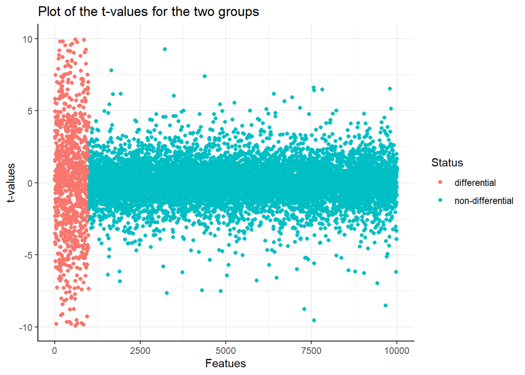

```r
# Compute the t-values for each row
classical_t_stats <- numeric(nrow(y))

for (i in 1:nrow(y)) {
  group_0 <- y[i, grp == 0]
  group_1 <- y[i, grp == 1]

  t_result <- t.test(group_0, group_1, var.equal = TRUE)

  classical_t_stats[i] <- t_result$statistic
}

# Visualize the t-tests for the two groups
classical_df <- data.frame(Features = 1:length(classical_t_stats),
                           t = classical_t_stats,
                           Status = cols)

ggplot(classical_df, aes(x = Features, y = t, colour = Status)) +
  geom_point() +
  theme_bw() +
  theme(
    panel.border = element_blank(),
    axis.line = element_line(color = "black", linewidth = 0.5, lineend = "square")
  ) +
  ylim(-10, 10) +
  labs(x = "Featues", y = "t-values") +
  ggtitle("Plot of the t-values for the two groups")
```

We notice that the classical t-test produce similar results to the moderated t-test computed above. Now, we go on to analyze the log-fold changes in the two groups.

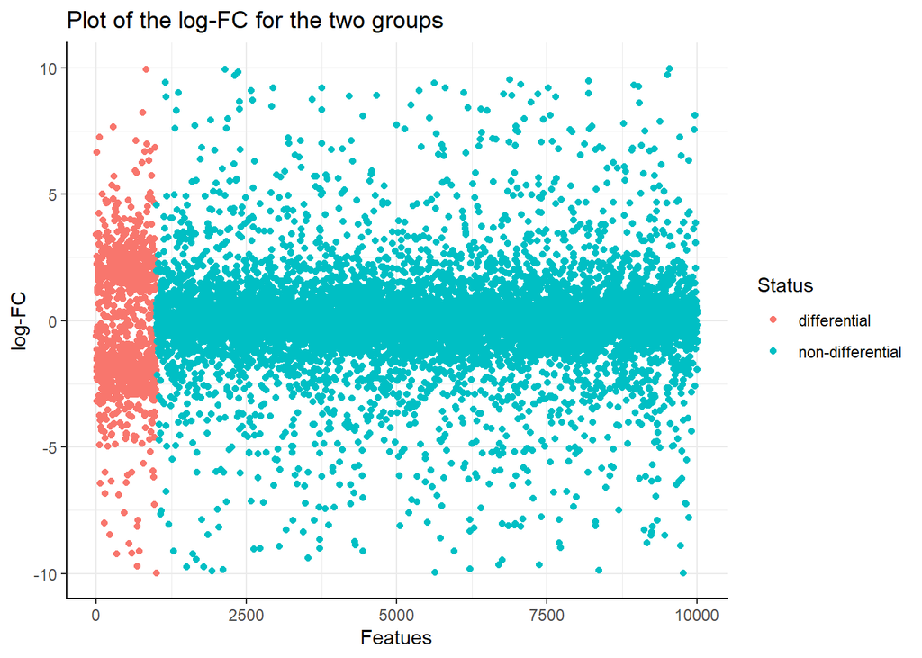

```r
# Visualize the log-fold changes
log_fold_changes_df <- data.frame(Features = 1:nrow(fit$coefficients),
                           log_FC = fit$coefficients[,2],
                           Status = cols)


ggplot(log_fold_changes_df, aes(x = Features, y = log_FC, colour = Status)) +
  geom_point() +
  theme_bw() +
  theme(
    panel.border = element_blank(),
    axis.line = element_line(color = "black", linewidth = 0.5, lineend = "square")
  ) +
  ylim(-10, 10) +
  labs(x = "Featues", y = "log-FC") +
  ggtitle("Plot of the log-FC for the two groups")
```

From what we observed, both the t-moderated values and the t-values separates better the true differential from the non-differential genes. However, using a metric to assert the best method to separate the two groups, we can state more precisely which one is better to discriminate between differential and non-differential ones.

## Question 5

*Pick a reasonable metric to compare the methods, such as an ROC curve, false discovery plot, power versus achieved FDR. Using this metric / curve, formally compare the performance of the classical t-test (calculated in Question 4), the moderated t-test (plotted above) and the log-fold-change or mean difference (fit$coef). Two packages that are useful for these kind of plots include: ROCR or iCOBRA.*

```r
classicalt <- vector(mode = "numeric", length = nrow(y))
classicalt_res <- list()
data <- list()
for (row in 1: nrow(y)){
  x0 <- y[row, grp == 0]
  x1 <- y[row, grp == 1]
  classicalt[row] <- t.test(x0, x1, alternative = "two.sided", var.equal = TRUE)$statistic
  classicalt_res <- append(classicalt_res, list(t.test(x0, x1, alternative = "two.sided", var.equal = TRUE)))
}

p_vals_class <- unlist(lapply(classicalt_res, function (x) x$p.value[[1]]))
p_vals_mod <- fit$p.value[, 2]
fc_vals <- abs(fit$coef[, 1] - fit$coef[, 2])
ground_truth <- rep(0, nrow(y))
ground_truth[1:max(indD)] <- rep(1, max(indD))
colors_roc = c("firebrick3", "dodgerblue4", "forestgreen")
```

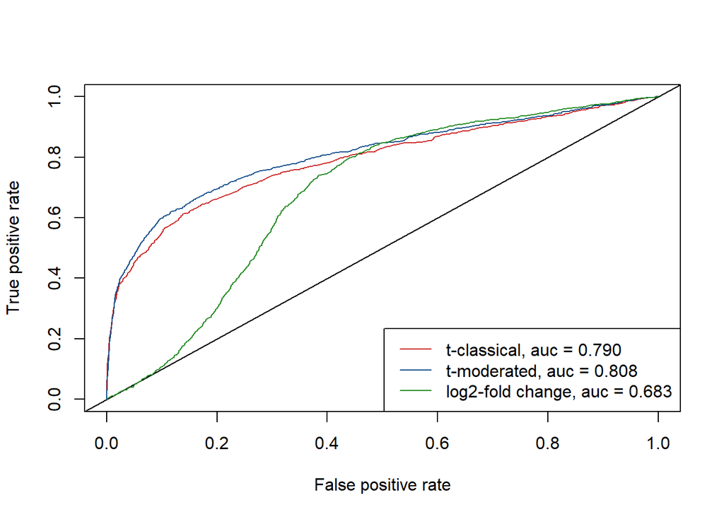

```r
samp_sizes <- seq(2*max(indD), nrow(y), by = 2*length(indD))
perf_class_container <- list()
perf_mod_container <- list()

for (it in 5){
  idxer <- rep(FALSE, nrow(y))
  samp_size <- samp_sizes[it]
  idxer[1: samp_size] <- rep(TRUE, samp_size)

  pred_class <- prediction(1 - p_vals_class[idxer], ground_truth[idxer])
  pred_mod <- prediction(1 - p_vals_mod[idxer], ground_truth[idxer])
  pred_fc <- prediction(fc_vals[idxer], ground_truth[idxer]*trueFC)

  perfc <- performance(pred_class, measure = "tpr", x.measure = "fpr")
  aucc <- performance(pred_class, measure = "auc")
  perfm <- performance(pred_mod, measure = "tpr", x.measure = "fpr")
  aucm <- performance(pred_mod, measure = "auc")
  perffc <-performance(pred_fc, measure = "tpr", x.measure = "fpr")
  aucfc <- performance(pred_fc, measure = "auc")

  plot(perfc, col = colors_roc[1])
  abline(a=0, b= 1)
  plot(perfm, add = TRUE, col = colors_roc[2])
  plot(perffc, add = TRUE, col = colors_roc[3])

  leg1 <- sprintf("t-classical, auc = %1.3f", round(unlist(aucc@y.values), 3))
  leg2 <- sprintf("t-moderated, auc = %1.3f", round(unlist(aucm@y.values), 3))
  leg3 <- sprintf("log2-fold change, auc = %1.3f", round(unlist(aucfc@y.values), 3))
  legend("bottomright", legend = c(leg1, leg2, leg3), col = colors_roc, lwd = 1, cex = 1,y.intersp = 1, ncol = 1)
}
```

From the ROC we computed the AUC and we noticed that the most effective statistics to best separate differential and non-differential genes is the t-moderated value.

## Question 6

```r
library("affy")
library("preprocessCore")
unzip("C:/Users/gianf/OneDrive/Documenti/DOCUMENTS_ETH/1 YEAR/1 SEMESTER/SAHTGTD/EXERCISES/affy_estrogen.zip")
ddir <- "affy_estrogen"
dir(ddir)
```

```
[1] "high10-1.cel" "high10-2.cel" "high48-1.cel" "high48-2.cel" "low10-1.cel"
[6] "low10-2.cel"  "low48-1.cel"  "low48-2.cel"  "targets.txt"
```

```r
# preprocess affymetrix data
targets <- readTargets("targets.txt", path=ddir)
targets$time.h <- factor(targets$time.h)
targets
```

```
      filename estrogen time.h
1  low10-1.cel   absent     10
2  low10-2.cel   absent     10
3 high10-1.cel  present     10
4 high10-2.cel  present     10
5  low48-1.cel   absent     48
6  low48-2.cel   absent     48
7 high48-1.cel  present     48
8 high48-2.cel  present     48
```

```r
abatch <- ReadAffy(filenames=targets$filename,
                   celfile.path=ddir)
eset <- rma(abatch)  # bg correct, normalize, summarize
```

```
Background correcting
Normalizing
Calculating Expression
```

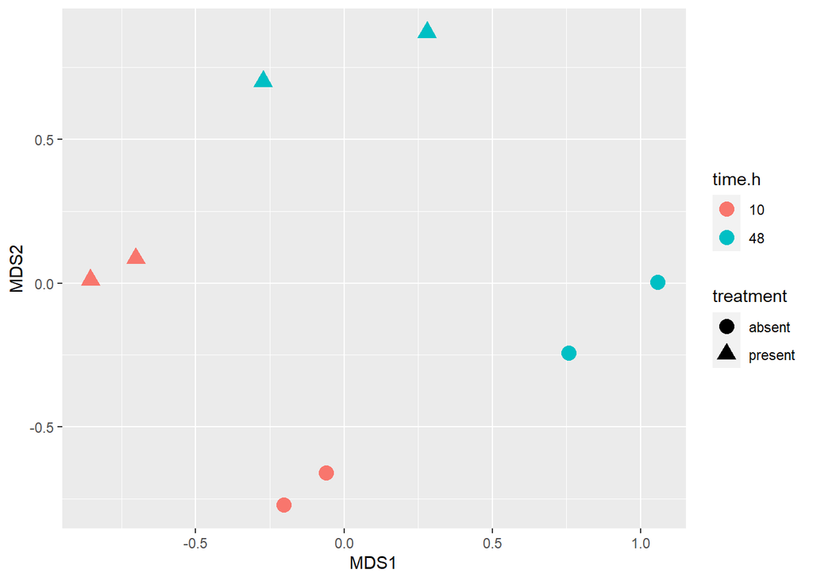

```r
mds <- plotMDS( exprs(eset), plot = FALSE)  # MDS plot

df <- data.frame(MDS1 = mds$x, MDS2 = mds$y,
                 treatment = targets$estrogen,
                 time.h = targets$time.h)
ggplot(df, aes(x = MDS1, y = MDS2, shape=treatment, colour=time.h)) +
  geom_point(size = 4)
```

```r
# do the limma modeling
f <- paste0(targets$estrogen, targets$time.h)
f <- factor(f)

# create design matrix
design <- model.matrix(~0+f)
colnames(design) <- levels(f)
design
```

```
  absent10 absent48 present10 present48
1        1        0         0         0
2        1        0         0         0
3        0        0         1         0
4        0        0         1         0
5        0        1         0         0
6        0        1         0         0
7        0        0         0         1
8        0        0         0         1
attr(,"assign")
[1] 1 1 1 1
attr(,"contrasts")
attr(,"contrasts")$f
[1] "contr.treatment"
```

```r
fit <- lmFit(eset, design)
```

```r
cont.matrix <- makeContrasts(E10="present10-absent10",
                             E48="present48-absent48",
                             Time="absent48-absent10",levels=design)
cont.matrix
```

```
           Contrasts
Levels      E10 E48 Time
  absent10   -1   0   -1
  absent48    0  -1    1
  present10   1   0    0
  present48   0   1    0
```

```r
fit2  <- contrasts.fit(fit, cont.matrix)
fit2  <- eBayes(fit2)
class(fit2)
```

```
[1] "MArrayLM"
attr(,"package")
[1] "limma"
```

```r
names(fit2)
```

```
 [1] "coefficients"     "rank"             "assign"           "qr"
 [5] "df.residual"      "sigma"            "cov.coefficients" "stdev.unscaled"
 [9] "pivot"            "Amean"            "method"           "design"
[13] "contrasts"        "df.prior"         "s2.prior"         "var.prior"
[17] "proportion"       "s2.post"          "t"                "df.total"
[21] "p.value"          "lods"             "F"                "F.p.value"
```

```r
topTable(fit2, coef=1, n=5)
```

```
            logFC   AveExpr        t      P.Value    adj.P.Val        B
39642_at 2.939428  7.876515 23.71715 4.741579e-09 3.128295e-05 9.966810
910_at   3.113733  9.660238 23.59225 4.955715e-09 3.128295e-05 9.942522
31798_at 2.800195 12.115778 16.38509 1.025747e-07 3.511070e-04 7.977290
41400_at 2.381040 10.041553 16.22463 1.112418e-07 3.511070e-04 7.916921
40117_at 2.555282  9.676557 15.68070 1.472942e-07 3.576234e-04 7.705093
```

```r
topTable(fit2, coef=2, n=5)
```

```
            logFC   AveExpr        t      P.Value    adj.P.Val         B
910_at   3.855061  9.660238 29.20918 8.266125e-10 1.043598e-05 11.606193
31798_at 3.597334 12.115778 21.04947 1.284430e-08 7.631722e-05  9.890557
1854_at  3.340896  8.532099 20.19564 1.813478e-08 7.631722e-05  9.641399
38116_at 3.758891  9.513109 16.85669 8.116230e-08 2.511100e-04  8.480197
38065_at 2.993641  9.097183 16.20914 1.121213e-07 2.511100e-04  8.214175
```

The argument coef specifies the contrast for which toptable should be generated. In this case, coef=1 generates a top table for the contrast E10=“present10-absent10”, while coef=2 generates a top table for the contrast E48=“present48-absent48”.

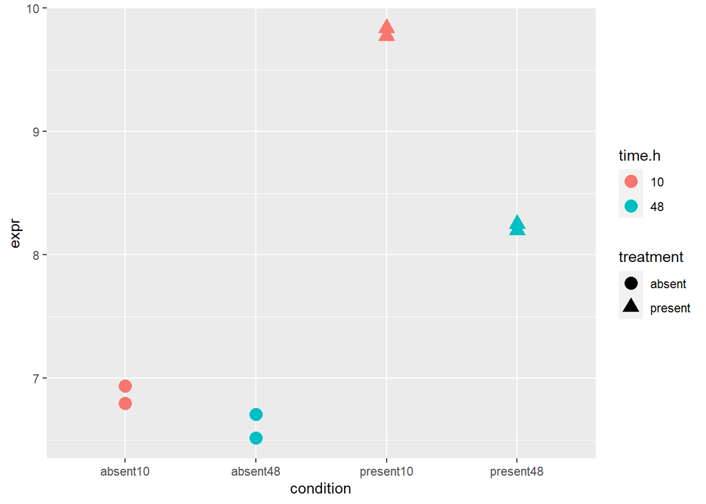

```r
df <- cbind(df, expr = exprs(eset)["39642_at",])
df$condition <- paste0(df$treatment, df$time.h)

ggplot(df, aes(x = condition, y = expr, shape=treatment, colour=time.h)) +
  geom_point(size = 4)
```

*From the matrix of summarized Affymetrix data that went into the limma pipeline in the first place (exprs(eset)), manually calculate the logFC and AveExpr for one of the top differentially expressed features.*

```r
gene_of_interest <- "910_at"
expression_values <- exprs(eset)[gene_of_interest, ]

# Compute the log-FC
mean_treatment <- mean(expression_values[df$treatment == "present"])
mean_control <- mean(expression_values[df$treatment == "absent"])
logFC <- log2(mean_treatment) - log2(mean_control)

# Compute the average expression
ave_expr <- mean(log2(expression_values))

cat("LogFC:", logFC, "\n")
```

```
LogFC: 0.526127
```

```r
cat("AveExpr:", ave_expr, "\n")
```

```
AveExpr: 3.245318
```